lab note

# smart_openによる統一的なファイルアクセス

Accessing file with unified pythonic API

Oct 21, 2020 • 1 min read

Cloud Python AWS GCP

- はじめに
- やったこと
- smart_openについて
- クラウドストレージ，Webからファイルを読み込む
- pathlib.Path経由でsmart_openを使うことはできるようですが
- 参考

## はじめに

ファイルの格納先(ファイルシステム，S3，GCS等)毎にIO処理を記述すると，プログラムが複雑になりがちです．ここでは，それらを統一的に取り扱うことができるsmart_openについて述べます．

## やったこと

- smart_openの導入
- smart_openによるファイルシステム，クラウドストレージ，Webからのファイル読み込み

## smart_openについて

smart_openはビルトインのopenを置き換えることで，様々なプロトコルを用いてファイルをオープンすることを可能にします．現状のプロトコルに対応している様です．

- S3
- GCS
- Blob Storage
- HDFS
- ファイルシステム
- SSH
- SCP
- SFTP
- HTTP

また，以下形式で圧縮されたファイルを透過的に扱うことができます．

- gzip
- bzip2

従って，以下のようにクラウドストレージをサポートするsmart_openを導入します．

```
$ pip install smart_open[all]
```

他の導入方法については，[リポジトリのREADME](https://github.com/RaRe-Technologies/smart_open)を参考にしてください．

## クラウドストレージ，Webからファイルを読み込む

通常，クラウドストレージ上のファイルにアクセスするには専用のSDKを使用することが多いと思います． また，HTTPプロトコルでアクセスするには，urllibやrequests等を使用することが多いと思います． そのため，リソースに応じてこれらのライブラリを適切に取り扱う必要があります．

smart_openはこれらのライブラリを適切にラップします．従って，これらのファイルをファイルシステム上にあるかの様に取り扱うことが可能となります．

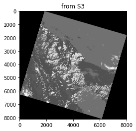

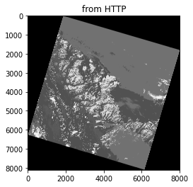

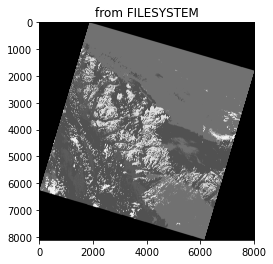

```python
from smart_open import open
import matplotlib.pyplot as plt
from PIL import Image

sources = {
    "S3": "s3://landsat-pds/L8/003/017/LC80030172015001LGN00/LC80030172015001LGN00_BQA.TIF",
    "HTTP":  "https://s3-us-west-2.amazonaws.com/landsat-pds/L8/003/017/LC80030172015001LGN00/LC80030172015001LGN00_BQA.TIF",
    "FILESYSTEM": "/tmp/LC80030172015001LGN00_BQA.TIF"
}

for protocol, url in sources.items():
    with open(url, "rb") as fp:
        img = Image.open(fp)
        plt.figure()
        plt.title(f"from {protocol}")
        plt.imshow(img, cmap='gray')
```

## pathlib.Path経由でsmart_openを使うことはできるようですが

いかなるリソースもopenで同様に取り扱うことができる事はとても便利です．しかしながら，`str`でリソースを指定するのは少し大変です．なので，`pathlib.Path`でリソースを指定できると便利です．

smart_openは`pathlib.Path.open`をフックすることできるようです．しかしながら，`pathlib.Path`がファイルパスしか扱えない(//が/に置換されてしまう)ので，すこし微妙かもしれません．．

```python
from pathlib import Path
Path("https://s3-us-west-2.amazonaws.com/landsat-pds/L8/003/017/LC80030172015001LGN00/LC80030172015001LGN00_BQA.TIF")
```

```
PosixPath('https:/s3-us-west-2.amazonaws.com/landsat-pds/L8/003/017/LC80030172015001LGN00/LC80030172015001LGN00_BQA.TIF')
```

## 参考

- smart_open